# GLM: Vitamin C in Orange juice

One wants to compare the evolution in time of the Vitamin C level of an orange juice, as a function of: the type of container and the conservation temperature. To that end, three conservation methods where considered: “a”“,”b" and “c”.

For each conservation method, and during 12 weeks, two units of orange juice where analyzed. The structure of the dataset is as follows: the first column corresponds to the Treatment: conservation method, second column corresponds to Week: and it indicates the time after packaging, the third column indicates corresponds to VitC: level of vitamin C that has been observed.

```r
library(car)
library(tables)
library(emmeans)
dd <- read.csv2("vitc.csv")
head(dd)
```

```
##   treat week vitc
## 1     a    1 30.2
## 2     a    2 29.2
## 3     a    3 23.8
## 4     a    4 27.4
## 5     a    5 16.8
## 6     a    6 29.6
```

It is supposed that the Vitamin C level evolves following the exponential function:
$$VitC=\alpha_ie^{−\beta_i\cdot Week},$$

with $\alpha_i > 0$ and $\beta_i > 0$, and that these parameters may depend on the conservation method, indicated by the subscript $i$. Assuming that in the moment of packaging may exists differences between the levels of Vitamin C, and using a significance level equal to 5%, answer the following questions:

1. Define a generalized linear model with the “gamma” family, use it to check whether the treatments lose Vitamin C at the same velocity, that is if $\beta_1=\beta_2=\beta_3$ or not, and also to see if the three values of $\alpha_i$ are or are not statistically equivalent. From this model, estimate $\alpha_i$. Are they statistically different? Estimate $\beta_i$. Are they statistically different?

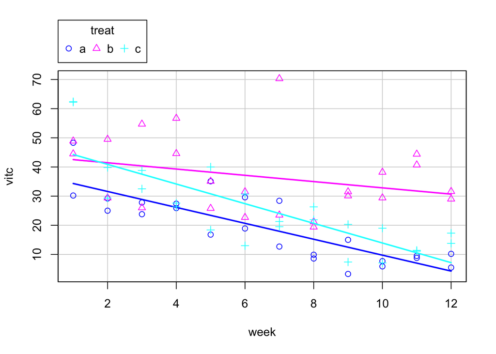

```r
sp(vitc~week|treat, smooth=F, data=dd)
```

Quin link fem servir? EL logaritme, la part lineal està a l’exponent i per tant si volem aïllar la part lineal hauriem d’utilitzar el link log. El tractament és l’efecte que podriem eliminar si dóna el mateix en els tres grups. Però a la descriptiva es veu que hi ha diferències. Per això, de moment ho inclourem:

```r
summary(model<-glm(vitc~treat*week, family=Gamma(link="log"), data=dd))
```

```
##
## Call:
## glm(formula = vitc ~ treat * week, family = Gamma(link = "log"),
##     data = dd)
##
## Deviance Residuals:
##      Min        1Q    Median        3Q       Max
## -1.02691  -0.25019  -0.06136   0.18828   0.75558
##
## Coefficients:
##             Estimate Std. Error t value Pr(>|t|)
## (Intercept)  3.84653    0.14949  25.731  < 2e-16 ***
## treatb      -0.06931    0.21141  -0.328    0.744
## treatc       0.12314    0.21141   0.582    0.562
## week        -0.15729    0.02031  -7.744 7.61e-11 ***
## treatb:week  0.12933    0.02872   4.502 2.80e-05 ***
## treatc:week  0.03066    0.02872   1.067    0.290
## ---
## Signif. codes:  0 '***' 0.001 '**' 0.01 '*' 0.05 '.' 0.1 ' ' 1
##
## (Dispersion parameter for Gamma family taken to be 0.1179906)
##
##     Null deviance: 24.790  on 71  degrees of freedom
## Residual deviance:  8.217  on 66  degrees of freedom
## AIC: 514.38
##
## Number of Fisher Scoring iterations: 5
```

Hem de fer els diagnòstics i l’estudi dels efectes. Una visió descriptiva del models:

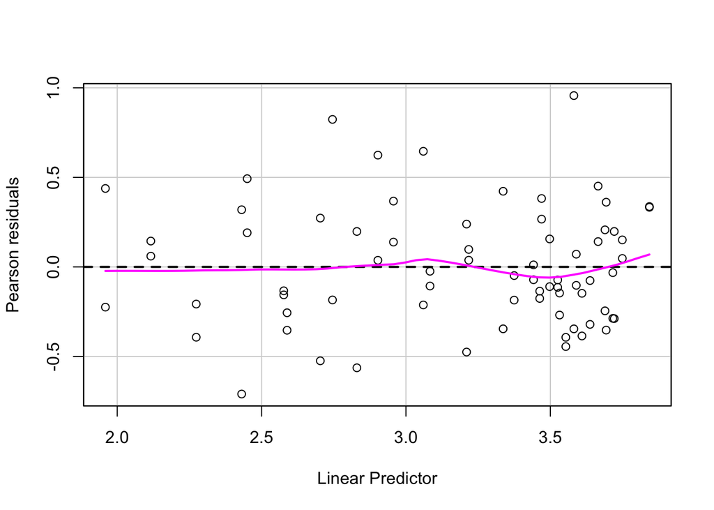

```r
residualPlot(model, ty="pearson")
```

És igual si agafem el predictor lineal o la Vitamina C predita, o si agafem els residuals de Pearson o els de la Deviància. Han d’anar al voltant de zero i no hem de veure patrons. La concentració que veiem és simplement una qüestions de com han sortit aquestes dades. No veiem cap patró, la gràfica és acceptable. Podem tenir idea si les variàncies van canviant amb la següent gràfica:

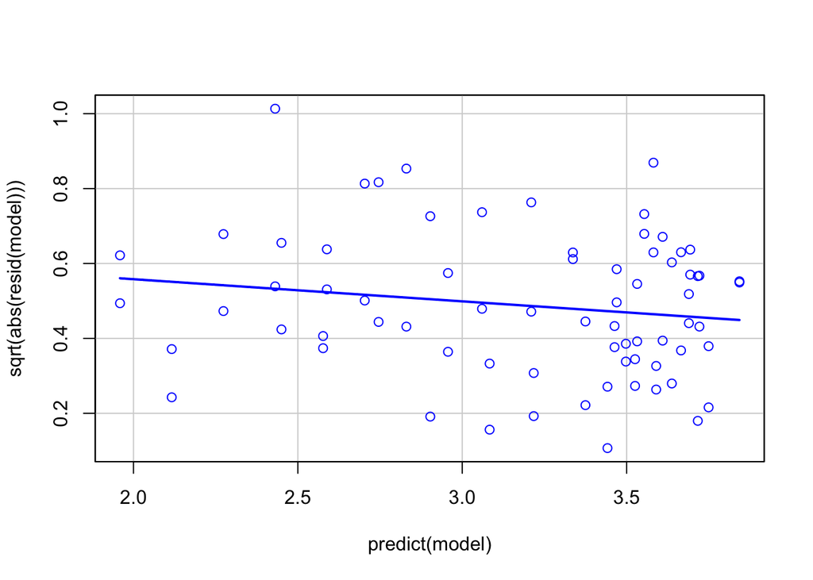

```r
scatterplot(predict(model), sqrt(abs(resid(model))), smooth=F, boxplot=F)
```

Les variàncies van disminuint una mica.

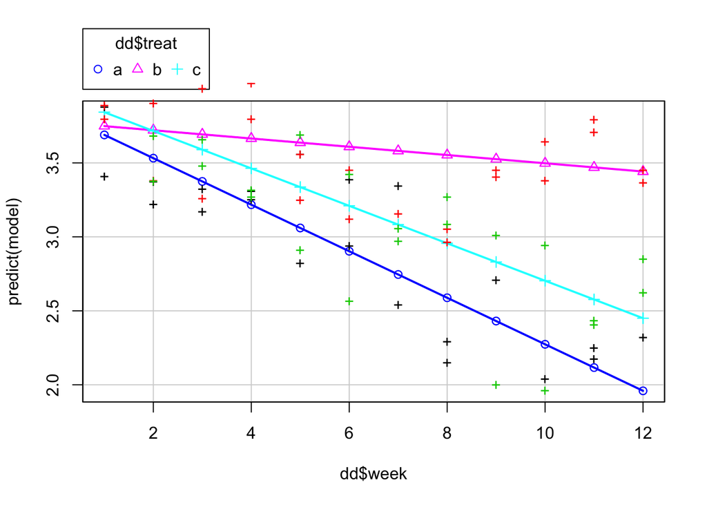

```r
sp(predict(model)~dd$week|dd$treat, smooth=F)
points(dd$week, log(dd$vitc), pch="+", col=dd$treat)
```

Suposem que acceptem el model i que els diagnòstics són acceptables. EL primer pas és fer le test Anova (II).

```r
Anova(model, test.statistic="F")
```

```
## Analysis of Deviance Table (Type II tests)
##
## Response: vitc
## Error estimate based on Pearson residuals
##
##            Sum Sq Df F value    Pr(>F)
## treat      7.4194  2  31.441 2.563e-10 ***
## week       8.9695  1  76.019 1.375e-12 ***
## treat:week 2.6655  2  11.296 6.040e-05 ***
## Residuals  7.7874 66
## ---
## Signif. codes:  0 '***' 0.001 '**' 0.01 '*' 0.05 '.' 0.1 ' ' 1
```

```r
CLD(emmg<-emmeans(model, ~treat|week, at=list(week=c(0,12))), reversed = TRUE)
```

```
## week =  0:
##  treat   emmean        SE  df asymp.LCL asymp.UCL .group
##  c     3.969668 0.1494881 Inf  3.676677  4.262660  1
##  a     3.846529 0.1494881 Inf  3.553537  4.139520  1
##  b     3.777219 0.1494881 Inf  3.484228  4.070211  1
##
## week = 12:
##  treat   emmean        SE  df asymp.LCL asymp.UCL .group
##  b     3.441699 0.1318941 Inf  3.183192  3.700207  1
##  c     2.450102 0.1318941 Inf  2.191595  2.708610   2
##  a     1.959079 0.1318941 Inf  1.700571  2.217587    3
##
## Results are given on the log (not the response) scale.
## Confidence level used: 0.95
## P value adjustment: tukey method for comparing a family of 3 estimates
## significance level used: alpha = 0.05
```

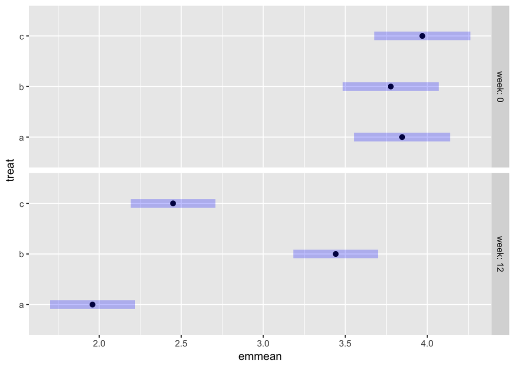

```r
plot(emmg)
```